# Ex13 Descriptiva iogurts

PIE2

Tardor 2019-2020

#### El mateix enunciat de l’exercici dels iogurts però ara tenim totes les dades al fitxer ”Iogurt.csv”.

S’ha fet un seguiment de iogurts en la fase de comercialització, per comparar l’efecte de la temperatura de la fermentació.

Individus: Unitats de iogurt, de cada temperatura de fermentació, analitzades alguns dies després:

Dues variables explicatòries:

• Dies: transcorreguts entre la fermentació i l’anàlisi del iogurt.

• Grups: Dos temperatures de la fermentació 42° o 43.5°.

Tres variables resposta mesuradesdurant l’experiència:

• pH: del iogurt.

• Strep.: concentració de Streptococcus salivarius thermophilus

• Lactob.: concentració de Lactobacillus delbrueckii bulgaricus

Utilitzant el programa R, contesteu els apartats següents:

*Comencem posant el directòri de treball, llegint i mirant les dades, definint el factor dia i carregant els paquests necessaris:*

```r
#setwd("...")

dd<-read.csv2("../Dades/Iogurt.csv")
dd
```

```
##     Ferm dia   pH strep lactob
## 1    T42  21 4.10  7.43   7.46
## 2    T42   0 4.44  7.65   7.75
## 3    T42  21 4.02  7.10   7.35
## 4    T42   7 4.24  7.54   7.62
## 5    T42   7 4.27  7.54   7.66
## 6    T42  28 4.01  7.25   7.41
## 7    T42   7 4.24  7.44   7.58
## 8    T42  14 4.09  7.33   7.46
## 9    T42   7 4.20  7.30   7.58
## 10   T42  21 4.06  7.28   7.41
## 11   T42   0 4.47  7.70   7.74
## 12   T42   7 4.20  7.48   7.51
## 13   T42   7 4.23  7.46   7.62
## 14   T42  28 3.97  6.99   7.31
```

[output cut: 46 more lines]

```r
dd$Fdia<-as.factor(dd$dia)

library(car)
library(tables)
```

**a)** Per les tres variables mesurades, descriviu les dades amb:

**i.** Diagrames de dispersió de l’estil

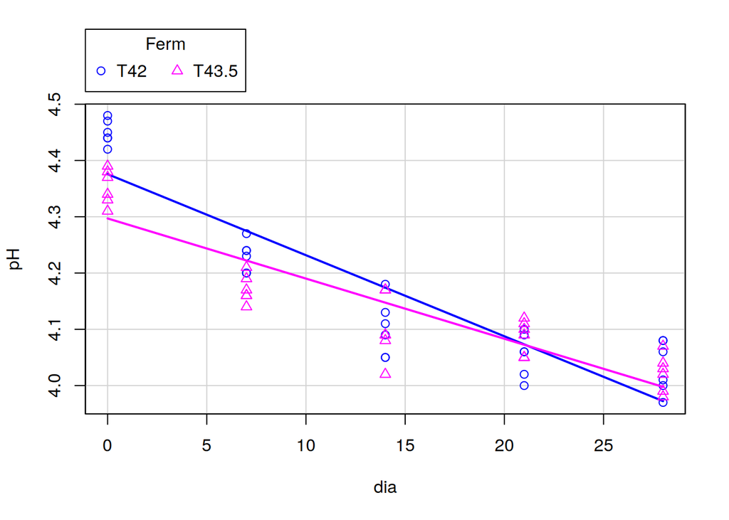

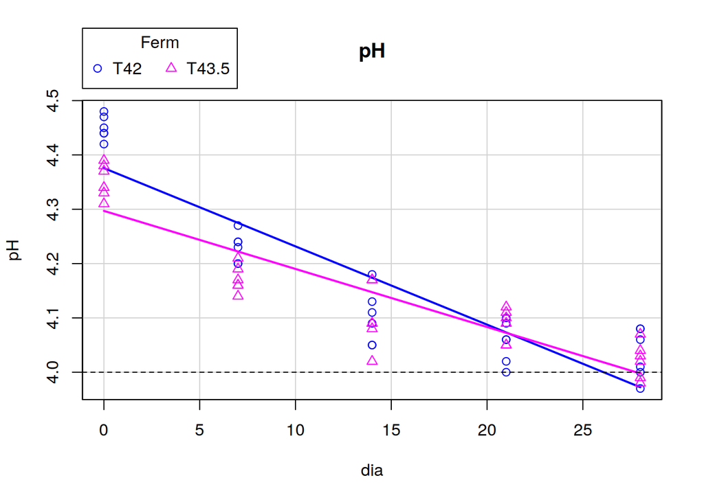

```r
sp(pH~dia|Ferm,dd,smooth=F,main="pH")
abline(h=4,lt=2)
```

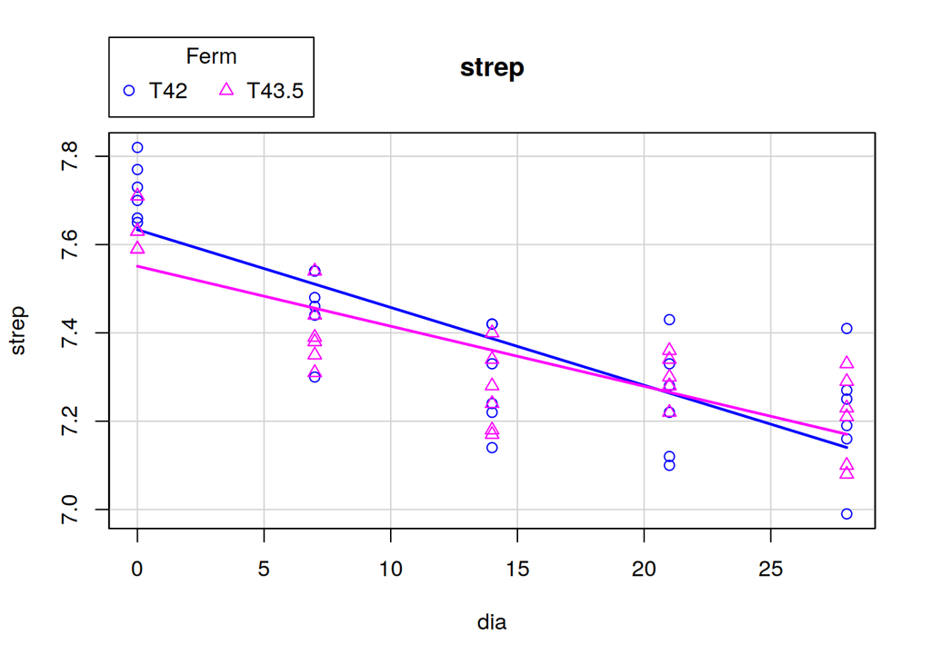

```r
sp(strep~dia|Ferm,dd,smooth=F,main="strep")
```

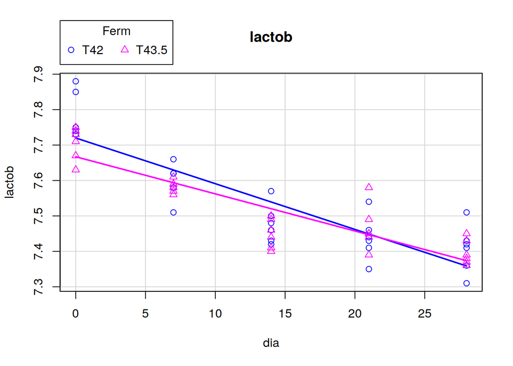

```r
sp(lactob~dia|Ferm,dd,smooth=F,main="lactob")
```

**ii.** Taules de l’estil

```
##
##                   Fdia
##      Ferm            0       7      14      21      28
##  pH   T42 mean 4.45000 4.23000 4.10167 4.05500 4.03333
##             sd 0.02191 0.02683 0.04997 0.03886 0.04633
##     T43.5 mean 4.35333 4.17167 4.10333 4.08667 4.02167
##             sd 0.03141 0.02483 0.05785 0.03011 0.03312
```

```r
print(tabular((strep)*Ferm*(mean+sd)~Fdia,dd),justification="r")
```

```
##
##                      Fdia
##         Ferm            0       7      14      21     28
##  strep   T42 mean 7.72167 7.46000 7.29500 7.24667 7.2117
##                sd 0.06555 0.08854 0.11415 0.12644 0.1389
##        T43.5 mean 7.63000 7.40167 7.26833 7.29667 7.2067
##                sd 0.04382 0.08035 0.09042 0.04967 0.1001
```

```r
print(tabular((lactob)*Ferm*(mean+sd)~Fdia,dd),justification="r")
```

```
##
##                       Fdia
##          Ferm            0       7      14      21      28
##  lactob   T42 mean 7.78000 7.59500 7.47667 7.43833 7.40667
##                 sd 0.06693 0.05128 0.05465 0.06242 0.06772
##         T43.5 mean 7.70500 7.58333 7.45000 7.46667 7.39667
##                 sd 0.04637 0.01751 0.04099 0.06408 0.03559
```

**b)** Inmediatament després de la fermentació, dia 0, amb $\alpha=0.05$ contesteu les preguntes

**i.** hi ha diferències entre els valors esperats $\mu_{1}=E\left[pH_{|T42}\right]$ i $\mu_{2}=E\left[pH_{|T43.5}\right]$?

```r
# Hem d'utilitzar les dades
d0<-dd[dd$dia==0,]
# Si considerem variàncies iguals
t.test(pH~Ferm,var.equal=T,d0)
```

```
##
##  Two Sample t-test
##
## data:  pH by Ferm
## t = 6.1828, df = 10, p-value = 0.0001038
## alternative hypothesis: true difference in means is not equal to 0
## 95 percent confidence interval:
##  0.06183034 0.13150299
## sample estimates:
##   mean in group T42 mean in group T43.5
##            4.450000            4.353333
```

```r
t.test(strep~Ferm,var.equal=T,d0)
```

```
##
##  Two Sample t-test
##
## data:  strep by Ferm
## t = 2.8478, df = 10, p-value = 0.01732
## alternative hypothesis: true difference in means is not equal to 0
## 95 percent confidence interval:
##  0.01994582 0.16338751
## sample estimates:
##   mean in group T42 mean in group T43.5
##            7.721667            7.630000
```

```r
t.test(lactob~Ferm,var.equal=T,d0)
```

```
##
##  Two Sample t-test
##
## data:  lactob by Ferm
## t = 2.2562, df = 10, p-value = 0.04767
## alternative hypothesis: true difference in means is not equal to 0
## 95 percent confidence interval:
##  0.0009332326 0.1490667674
## sample estimates:
##   mean in group T42 mean in group T43.5
##               7.780               7.705
```

```r
# Si considerem variàncies no iguals
t.test(pH~Ferm,d0)
```

```
##
##  Welch Two Sample t-test
##
## data:  pH by Ferm
## t = 6.1828, df = 8.9338, p-value = 0.0001673
## alternative hypothesis: true difference in means is not equal to 0
## 95 percent confidence interval:
##  0.06125851 0.13207482
## sample estimates:
##   mean in group T42 mean in group T43.5
##            4.450000            4.353333
```

```r
t.test(strep~Ferm,d0)
```

```
##
##  Welch Two Sample t-test
##
## data:  strep by Ferm
## t = 2.8478, df = 8.7248, p-value = 0.01975
## alternative hypothesis: true difference in means is not equal to 0
## 95 percent confidence interval:
##  0.0184992 0.1648341
## sample estimates:
##   mean in group T42 mean in group T43.5
##            7.721667            7.630000
```

```r
t.test(lactob~Ferm,d0)
```

```
##
##  Welch Two Sample t-test
##
## data:  lactob by Ferm
## t = 2.2562, df = 8.9007, p-value = 0.0508
## alternative hypothesis: true difference in means is not equal to 0
## 95 percent confidence interval:
##  -0.0003256452  0.1503256452
## sample estimates:
##   mean in group T42 mean in group T43.5
##               7.780               7.705
```

*Si ho repetim per algun altre dia, per exemple el 28, queda:*

```r
# Hem d'utilitzar les dades
d28<-dd[dd$dia==28,]
# Si considerem variàncies iguals
t.test(pH~Ferm,var.equal=T,d28)
```

```
##
##  Two Sample t-test
##
## data:  pH by Ferm
## t = 0.5018, df = 10, p-value = 0.6267
## alternative hypothesis: true difference in means is not equal to 0
## 95 percent confidence interval:
##  -0.04013723  0.06347056
## sample estimates:
##   mean in group T42 mean in group T43.5
##            4.033333            4.021667
```

```r
t.test(strep~Ferm,var.equal=T,d28)
```

```
##
##  Two Sample t-test
##
## data:  strep by Ferm
## t = 0.071522, df = 10, p-value = 0.9444
## alternative hypothesis: true difference in means is not equal to 0
## 95 percent confidence interval:
##  -0.1507662  0.1607662
## sample estimates:
##   mean in group T42 mean in group T43.5
##            7.211667            7.206667
```

```r
t.test(lactob~Ferm,var.equal=T,d28)
```

```
##
##  Two Sample t-test
##
## data:  lactob by Ferm
## t = 0.32017, df = 10, p-value = 0.7554
## alternative hypothesis: true difference in means is not equal to 0
## 95 percent confidence interval:
##  -0.05959343  0.07959343
## sample estimates:
##   mean in group T42 mean in group T43.5
##            7.406667            7.396667
```

```r
# Si considerem variàncies no iguals
t.test(pH~Ferm,d28)
```

```
##
##  Welch Two Sample t-test
##
## data:  pH by Ferm
## t = 0.5018, df = 9.0513, p-value = 0.6278
## alternative hypothesis: true difference in means is not equal to 0
## 95 percent confidence interval:
##  -0.04088271  0.06421604
## sample estimates:
##   mean in group T42 mean in group T43.5
##            4.033333            4.021667
```

```r
t.test(strep~Ferm,d28)
```

```
##
##  Welch Two Sample t-test
##
## data:  strep by Ferm
## t = 0.071522, df = 9.0914, p-value = 0.9445
## alternative hypothesis: true difference in means is not equal to 0
## 95 percent confidence interval:
##  -0.1529023  0.1629023
## sample estimates:
##   mean in group T42 mean in group T43.5
##            7.211667            7.206667
```

```r
t.test(lactob~Ferm,d28)
```

```
##
##  Welch Two Sample t-test
##
## data:  lactob by Ferm
## t = 0.32017, df = 7.5659, p-value = 0.7575
## alternative hypothesis: true difference in means is not equal to 0
## 95 percent confidence interval:
##  -0.06275111  0.08275111
## sample estimates:
##   mean in group T42 mean in group T43.5
##            7.406667            7.396667
```

**ii.** i entre les variancies $\sigma_{1}^{2}=Var\left(pH_{|T42}\right)$ i $\sigma_{2}^{2}=Var\left(pH_{|T43.5}\right)$?

```r
# Pel dia 0 ja tenom d0
var.test(pH~Ferm,d0)
```

```
##
##  F test to compare two variances
##
## data:  pH by Ferm
## F = 0.48649, num df = 5, denom df = 5, p-value = 0.4479
## alternative hypothesis: true ratio of variances is not equal to 1
## 95 percent confidence interval:
##  0.06807452 3.47661819
## sample estimates:
## ratio of variances
##          0.4864865
```

```r
var.test(strep~Ferm,d0)
```

```
##
##  F test to compare two variances
##
## data:  strep by Ferm
## F = 2.2378, num df = 5, denom df = 5, p-value = 0.3973
## alternative hypothesis: true ratio of variances is not equal to 1
## 95 percent confidence interval:
##   0.3131441 15.9925107
## sample estimates:
## ratio of variances
##           2.237847
```

```r
var.test(lactob~Ferm,d0)
```

```
##
##  F test to compare two variances
##
## data:  lactob by Ferm
## F = 2.0837, num df = 5, denom df = 5, p-value = 0.4395
## alternative hypothesis: true ratio of variances is not equal to 1
## 95 percent confidence interval:
##   0.291577 14.891065
## sample estimates:
## ratio of variances
##           2.083721
```

Nota: podeu repetir l’apartat per a qualsevol dels 5 dies de les dades i qualsevol de les tres variables analitzades. El cas del dia 0 ja el tenim fet a mà a l’exercici 8) i amb R però entrant les dades a ma a l’exercici 12).

#### *Definint les dades com d0 o d28, ho podem fer per qualsevol dels dies*

**c)** Com que és molt més senzill obtenir el pH que la concentració de strep, o de lactob, voldriem predir-les a partir del pH.

**i.** Quina expressió senzilla donarieu per obtenir la concetració de strep a partir del pH? Si es considera que per sota de pH=4 el iogurt ha expirat quin seria el límit per strep?

```r
mod1<-lm(strep~pH,dd)
summary(mod1)
```

```
##
## Call:
## lm(formula = strep ~ pH, data = dd)
##
## Residuals:
##      Min       1Q   Median       3Q      Max
## -0.15814 -0.05035 -0.00171  0.04508  0.13758
##
## Coefficients:
##             Estimate Std. Error t value Pr(>|t|)
## (Intercept)  2.14327    0.28205   7.599 2.89e-10 ***
## pH           1.25715    0.06775  18.556  < 2e-16 ***
## ---
## Signif. codes:  0 '***' 0.001 '**' 0.01 '*' 0.05 '.' 0.1 ' ' 1
##
## Residual standard error: 0.07359 on 58 degrees of freedom
## Multiple R-squared:  0.8558, Adjusted R-squared:  0.8533
## F-statistic: 344.3 on 1 and 58 DF,  p-value: < 2.2e-16
```

```r
paste0("strep=",coef(mod1)[1],"+",coef(mod1)[2],"·pH")
```

```
## [1] "strep=2.14327020444606+1.25714544036707·pH"
```

```r
print(limit1<-sum(coef(mod1)*c(1,4)))
```

```
## [1] 7.171852
```

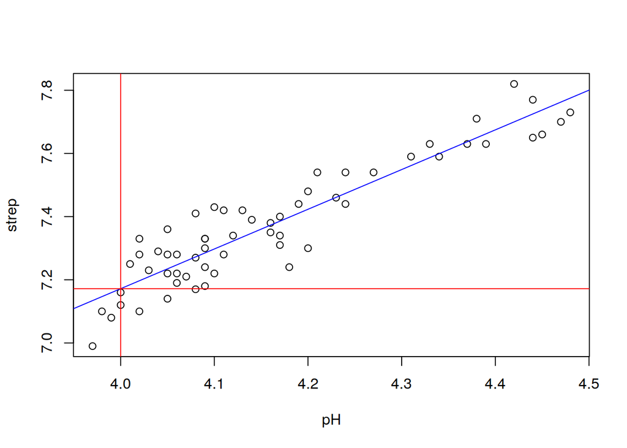

```r
# Gràfica
with(dd,plot(pH,strep))
abline(coef(mod1),col="blue")
abline(v=4,col="red")
abline(h=limit1,col="red")
```

**ii.** Quina expressió senzilla donarieu per obtenir la concetració de lactob a partir del pH? Si es considera que per sota de pH=4 el iogurt ha expirat quin seria el límit per lactob?

```r
mod2<-lm(lactob~pH,dd)
summary(mod2)
```

```
##
## Call:
## lm(formula = lactob ~ pH, data = dd)
##
## Residuals:
##       Min        1Q    Median        3Q       Max
## -0.086181 -0.033098 -0.000082  0.031023  0.117622
##
## Coefficients:
##             Estimate Std. Error t value Pr(>|t|)
## (Intercept)  3.79895    0.17497   21.71   <2e-16 ***
## pH           0.89670    0.04203   21.34   <2e-16 ***
## ---
## Signif. codes:  0 '***' 0.001 '**' 0.01 '*' 0.05 '.' 0.1 ' ' 1
##
## Residual standard error: 0.04565 on 58 degrees of freedom
## Multiple R-squared:  0.887,  Adjusted R-squared:  0.885
## F-statistic: 455.2 on 1 and 58 DF,  p-value: < 2.2e-16
```

```r
paste0("lactob=",coef(mod2)[1],"+",coef(mod2)[2],"·pH")
```

```
## [1] "lactob=3.79894971350429+0.896703321541991·pH"
```

```r
print(limit2<-sum(coef(mod2)*c(1,4)))
```

```
## [1] 7.385763
```

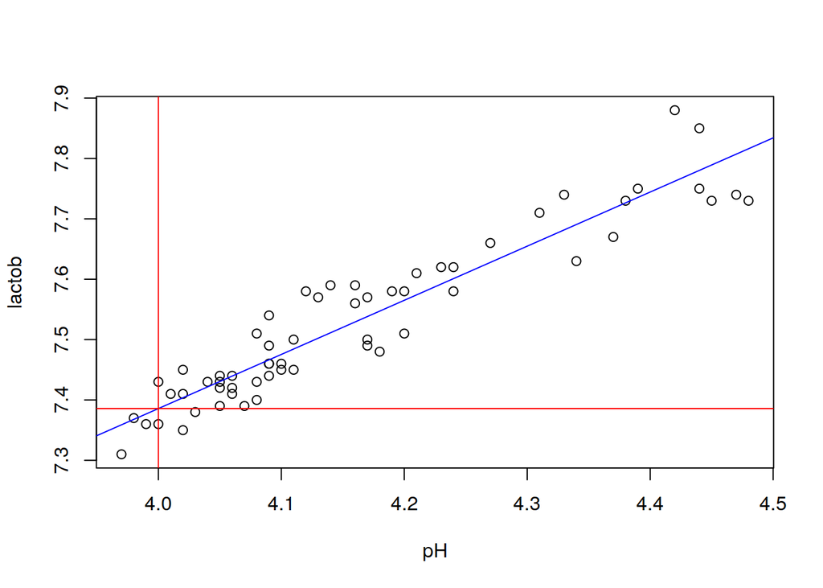

```r
# Gràfica
with(dd,plot(pH,lactob))
abline(coef(mod2),col="blue")
abline(v=4,col="red")
abline(h=limit2,col="red")
```

**iii.** Quina de les dues expressions anteriors us sembla que ajusta millor? per què?

#### *Molt iguals, una mica millor la del lactob pel coeficient de determinació lleugerament millor*